# Introducing tsibble: tidy temporal data frames and tools in R

A new tidy data structure to support exploration and modeling of temporal data

Earo Wang https://earo.me (Monash University) , Dianne Cook http://dicook.org (Monash University) , Rob J Hyndman http://robjhyndman.com (Monash University)  
2019-04-19

## Introduction

Going from raw temporal data to model-ready time series objects is painful. Time series required for modelling are the notably simplified format from the data in the wild: irregular or multiple time intervals, point events that need aggregating, multiple observational units or repeated measurements on multiple individuals, and heterogeneous data types. The lack of formal organisation on temporal data leads to ad hoc efforts, and the richness of data will be lost in transition. Mining temporal information from time series objects is often inhibited by limited toolkits that hinge on that specialist format. Figure 1 illustrates the lumpy workflow of current time series analysis.

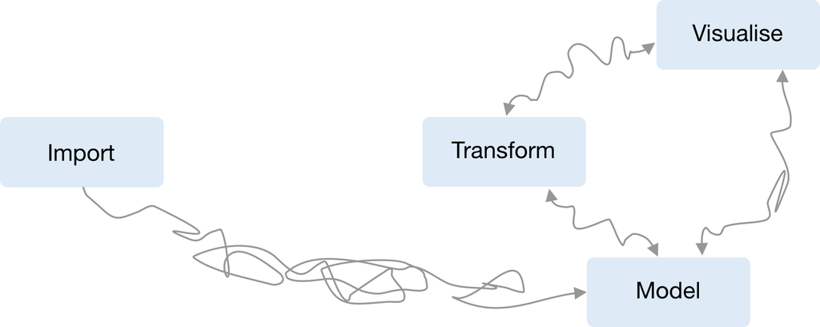

Figure 1: Illustration of the current time series analysis workflow, adapted from *R for Data Science*. The missing “tidy” temporal data structure leads to a myriad of ad hoc solutions and duplicated efforts from raw temporal data to model-oriented time series objects.

The **tsibble** package attempts to lubricate this process. It provides a new data abstraction to represent temporal data, referred to as “*tsibble*”, allowing the “tidy data” principles (Wickham 2014) to be brought to the time domain. It also helps to lay the plumbing for temporal data analysis modules of transformation, visualisation, and modeling, to achieve rapid iteration in gaining data insights.

## Note

A full paper on the data structure and design principles of the **tsibble** R package can be found at arXiv (https://arxiv.org/abs/1901.10257).

Wickham, Hadley. 2014. “Tidy Data.” *Journal of Statistical Software* 59 (10). Foundation for Open Access Statistics: 1–23.